# Lab 4

Kipras Varkala

04/13/2022

```r
dictionary <- readr::read_csv(here::here("data", "green-dictionary.csv"))
green_data <- readr::read_csv(here::here("data", "green-data.csv"))
```

## Questions

### 1. Inspect the item responses (e.g., with graphs or by summarizing distinct values). Is anything unusual?

```r
dictionary %>%
  glimpse()
```

```
## Rows: 36
## Columns: 4
## $ Item    <chr> "green1", "green2", "green3", "green4", "green5", "comp1", "co~
## $ Content <chr> "Overall, I am regarded as an environmentally conscious person~
## $ Options <chr> "1-5; SD, D, NAD, A, SA", "1-5; SD, D, NAD, A, SA", "1-5; SD, ~
## $ Keying  <dbl> 1, -1, 1, 1, 1, 1, 1, 1, 1, 1, -1, -1, -1, -1, -1, 1, 1, 1, 1,~
```

```r
green_data %>%
  glimpse()
```

```
## Rows: 373
## Columns: 37
## $ id      <dbl> 9099, 6275, 8116, 8586, 406, 5645, 3788, 8424, 8450, 512, 3972~
## $ green1  <dbl> 4, 3, 4, 4, 3, 4, 1, 4, 4, 4, NA, 3, 3, 4, 3, 4, 3, 4, 3, NA, ~
## $ green2  <dbl> 2, 5, 2, 3, 2, 3, 1, 3, 2, 2, NA, 2, 3, 3, 2, 2, 4, 2, 3, NA, ~
## $ green3  <dbl> 5, 3, 5, 5, 4, 4, 1, 2, 3, 5, NA, 4, 3, 3, 4, 5, 4, 5, 3, NA, ~
## $ green4  <dbl> 4, 3, 4, 4, 4, 4, 1, 2, 5, 5, NA, 3, 3, 3, 3, 5, 4, 4, 2, NA, ~
## $ green5  <dbl> 3, 1, 3, 3, 4, 3, 1, 2, 2, 4, NA, 3, 4, 3, 3, 4, 3, 4, 1, NA, ~
## $ comp1   <dbl> 2, 4, 4, 4, 4, 5, 3, 1, 4, 5, NA, 4, 3, 4, NA, 5, 4, 4, 4, NA,~
## $ comp2   <dbl> 5, 5, 5, 5, 4, 5, 3, 1, 4, 2, NA, 5, 3, 4, NA, 5, 2, 4, 4, NA,~
## $ comp3   <dbl> 4, 4, 5, 5, 4, 5, 3, 1, 4, 5, NA, 5, 4, 5, NA, 5, 4, 5, 4, NA,~
## $ comp4   <dbl> 4, 5, 4, 4, 4, 4, 3, 2, 4, 4, NA, 4, 2, 4, NA, 5, 4, 4, 5, NA,~
## $ comp5   <dbl> 2, 5, 5, 5, 4, 4, 3, 2, 4, 2, NA, 4, 3, 5, NA, 5, 4, 4, 4, NA,~
## $ comp6   <dbl> 2, 1, 1, 1, 2, 2, 3, 4, 1, 2, NA, 2, 3, 2, NA, 1, 4, 3, 2, NA,~
## $ comp7   <dbl> 2, 1, 2, 1, 2, 4, 3, 4, 2, 2, NA, 2, 3, 2, NA, 2, 2, 4, 3, NA,~
```

[output cut: 24 more lines]

-99 is not an intended rating option so we must change it to NA.

```r
green_data %>% #check
  select(-id) %>%
  unlist() %>%
  unique()
```

```
## [1]   4   3   1  NA   5   2 -99
```

```r
green_data <- #replace
  green_data %>%
  mutate(
    across(
      -id,
      \(x) recode(x, "1" = 1, "2" = 2, "3" = 3, "4" = 4, "5" = 5, "-99" = NA_real_)
    )
  )

green_data %>% #double check
  select(-id) %>%
  unlist() %>%
  unique()
```

```
## [1]  4  3  1 NA  5  2
```

```r
green_data <- #remove
  green_data %>%
  drop_na()

#reverse
reversed_key <- dictionary %>%
  filter(Keying == -1) %>%
  pull(Item)

green_data <-
  green_data %>%
  mutate(
    across(
      all_of(reversed_key),
      \(x) recode(x, "1" = 5, "2" = 4, "3" = 3, "4" = 2, "5" = 1))
    )
```

### 2. Compute total scores for the four scales. Recode variables as needed.

```r
raw_totals <-
green_data %>%
  rowwise() %>%
  mutate(
    id = id,
    green_total = mean(c_across(starts_with("green")), na.rm = TRUE),
    comp_total = mean(c_across(starts_with("comp")), na.rm = TRUE),
    intel_total = mean(c_across(starts_with("intel")), na.rm = TRUE),
    open_total = mean(c_across(starts_with("open")), na.rm = TRUE),
    student = factor(student),
    .before = everything()
  ) %>%
  ungroup()

Totals_separate <- raw_totals %>%
   select(
     c(green_total : open_total),
     student,
   )

head(raw_totals)
```

```
## # A tibble: 6 x 41
##   green_total comp_total intel_total open_total    id green1 green2 green3
##         <dbl>      <dbl>       <dbl>      <dbl> <dbl>  <dbl>  <dbl>  <dbl>
## 1         4          3.7         2.8        3.5  9099      4      4      5
## 2         2.2        4.8         3.5        3.1  6275      3      1      3
## 3         4          4.4         3.6        3.9  8116      4      4      5
## 4         3.8        4.6         3          3.9  8586      4      3      5
## 5         3.8        4           3.7        3.7   406      3      4      4
## 6         3.6        4.2         3.8        3.8  5645      4      3      4
## # ... with 33 more variables: green4 <dbl>, green5 <dbl>, comp1 <dbl>,
## #   comp2 <dbl>, comp3 <dbl>, comp4 <dbl>, comp5 <dbl>, comp6 <dbl>,
## #   comp7 <dbl>, comp8 <dbl>, comp9 <dbl>, comp10 <dbl>, intel1 <dbl>,
## #   intel2 <dbl>, intel3 <dbl>, intel4 <dbl>, intel5 <dbl>, intel6 <dbl>,
## #   intel7 <dbl>, intel8 <dbl>, intel9 <dbl>, intel10 <dbl>, open1 <dbl>,
## #   open2 <dbl>, open3 <dbl>, open4 <dbl>, open5 <dbl>, open6 <dbl>,
## #   open7 <dbl>, open8 <dbl>, open9 <dbl>, open10 <dbl>, student <fct>
```

```r
summary(Totals_separate)
```

```
##   green_total      comp_total     intel_total      open_total    student
##  Min.   :1.400   Min.   :1.900   Min.   :2.000   Min.   :1.800   2:178
##  1st Qu.:2.800   1st Qu.:3.700   1st Qu.:3.200   1st Qu.:3.200   1: 85
##  Median :3.200   Median :4.000   Median :3.600   Median :3.600
##  Mean   :3.287   Mean   :4.023   Mean   :3.547   Mean   :3.635
##  3rd Qu.:3.800   3rd Qu.:4.400   3rd Qu.:4.000   3rd Qu.:4.000
##  Max.   :5.000   Max.   :5.000   Max.   :4.900   Max.   :4.800
```

### 3. Rescale the variables so that they go from 0-100 instead of the original range. Name the recaled variables *_pomp.

```r
re_green_data <-
  raw_totals %>%
  mutate(
    across(
      green_total : open_total,
      function(x) datawizard::change_scale(x, range(1,5), to = c(0, 100)),
      .names = "{.col}_pomp"
    ),
    .after = id
  )

head(re_green_data)
```

```
## # A tibble: 6 x 45
##   green_total comp_total intel_total open_total    id green_total_pomp
##         <dbl>      <dbl>       <dbl>      <dbl> <dbl>            <dbl>
## 1         4          3.7         2.8        3.5  9099               75
## 2         2.2        4.8         3.5        3.1  6275               30
## 3         4          4.4         3.6        3.9  8116               75
## 4         3.8        4.6         3          3.9  8586               70
## 5         3.8        4           3.7        3.7   406               70
## 6         3.6        4.2         3.8        3.8  5645               65
## # ... with 39 more variables: comp_total_pomp <dbl>, intel_total_pomp <dbl>,
## #   open_total_pomp <dbl>, green1 <dbl>, green2 <dbl>, green3 <dbl>,
## #   green4 <dbl>, green5 <dbl>, comp1 <dbl>, comp2 <dbl>, comp3 <dbl>,
## #   comp4 <dbl>, comp5 <dbl>, comp6 <dbl>, comp7 <dbl>, comp8 <dbl>,
## #   comp9 <dbl>, comp10 <dbl>, intel1 <dbl>, intel2 <dbl>, intel3 <dbl>,
## #   intel4 <dbl>, intel5 <dbl>, intel6 <dbl>, intel7 <dbl>, intel8 <dbl>,
## #   intel9 <dbl>, intel10 <dbl>, open1 <dbl>, open2 <dbl>, open3 <dbl>, ...
```

### 4. Make plots that illustrate the distributions of the 4 POMP-scored variables.

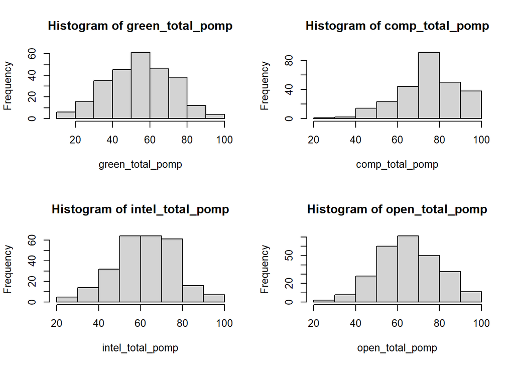

```r
attach(re_green_data)
par(mfrow=c(2,2))
hist(green_total_pomp)
hist(comp_total_pomp)
hist(intel_total_pomp)
hist(open_total_pomp)
```

### 5. Make scatterplots showing the relationships between green reputation and each personality trait. Include trend lines for students and non-students. What do these plots show?

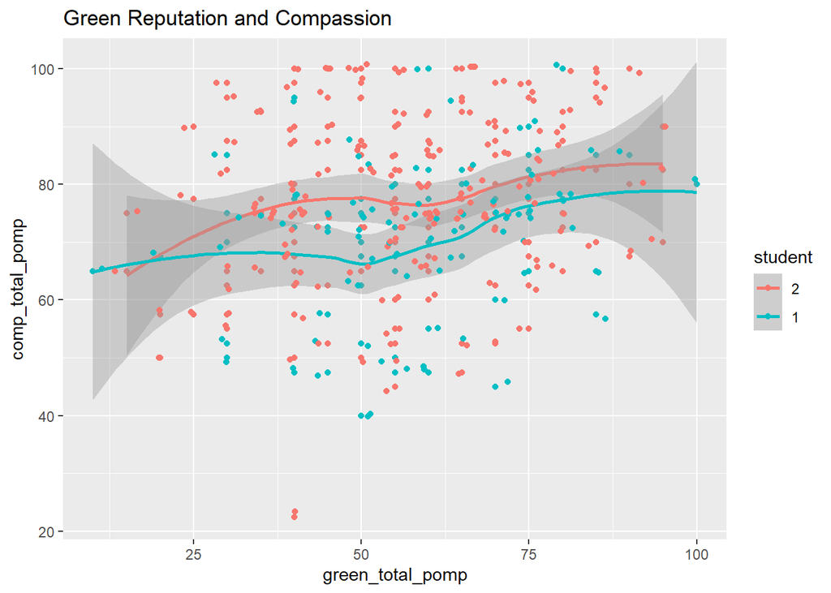

```r
ggplot(re_green_data) +
  aes(x = green_total_pomp, y = comp_total_pomp, color = student)+
  geom_point() +
  geom_smooth() +
  geom_jitter() +
  labs(title = 'Green Reputation and Compassion')
```

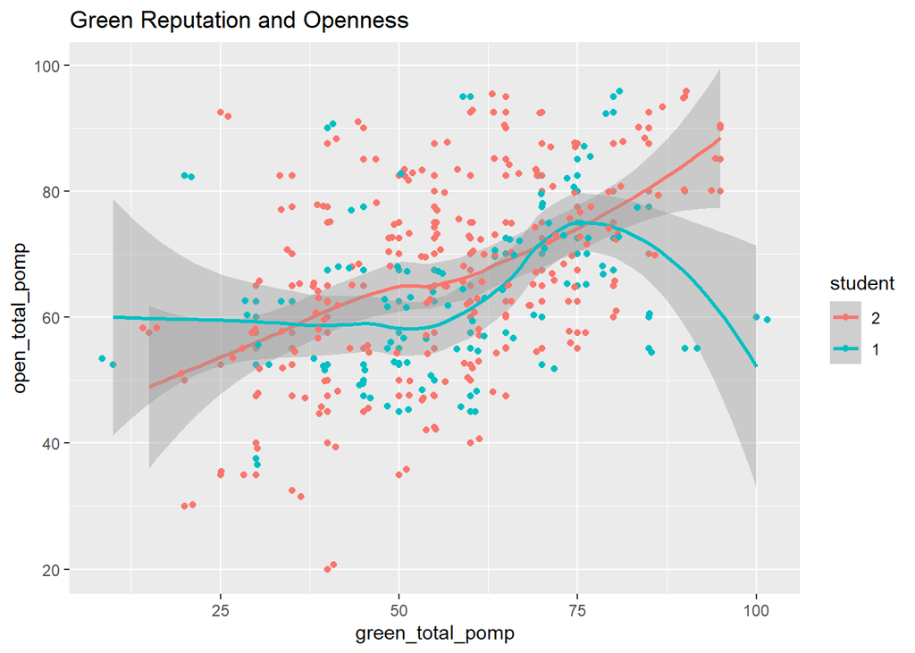

```r
ggplot(re_green_data) +
  aes(x = green_total_pomp, y = open_total_pomp, color = student)+
  geom_point() +
  geom_smooth() +
  geom_jitter() +
  labs(title = 'Green Reputation and Openness')
```

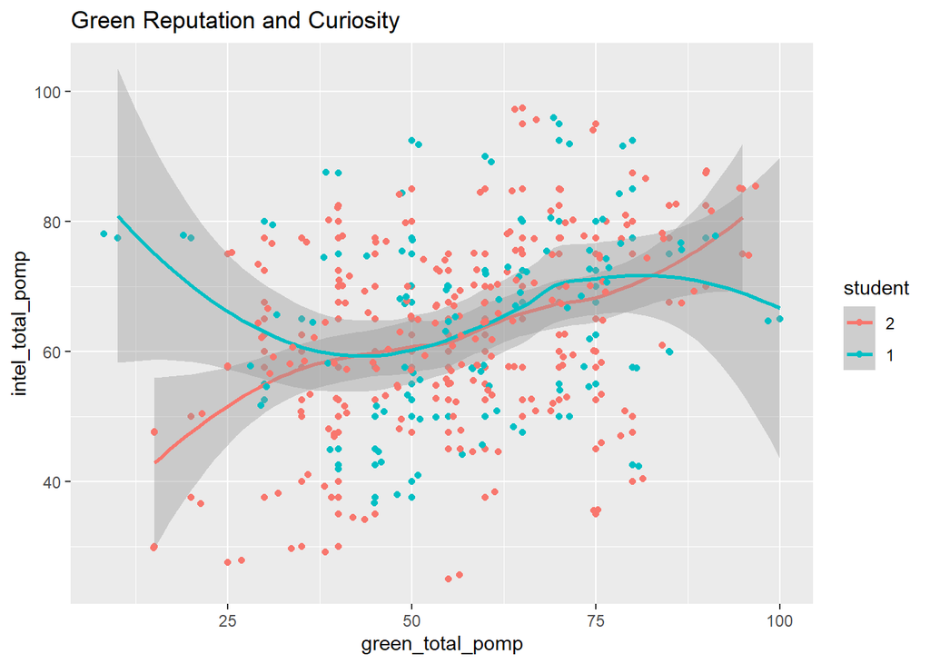

```r
ggplot(re_green_data) +
  aes(x = green_total_pomp, y = intel_total_pomp, color = student)+
  geom_point() +
  geom_smooth() +
  geom_jitter() +
  labs(title = 'Green Reputation and Curiosity')
```

Green reputation and compassion: pretty similar slightly positve linear relationship with students scoring slightly higher.

Green reputation and openness: aside from the outliers in non-student, both groups share a positive curvilinear relationship.

### 6. Compare green reputation for students and non-students using a rainfall plot (bar + density + data points).

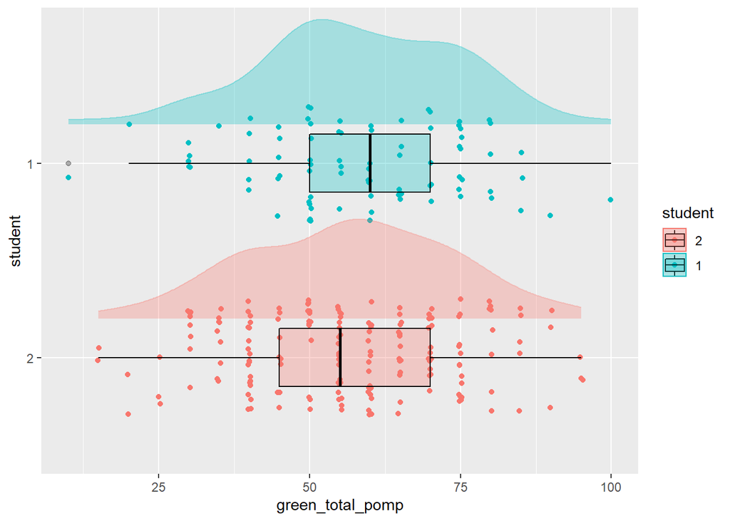

```r
ggplot(re_green_data) +
  aes(
    x = green_total_pomp,
    y = student,
    fill = student,
    color = student
    ) +
  geom_jitter(
    height = 0.3,
    width = 0.3
    ) +
  geom_boxplot(
    alpha = 0.3,
    width = 0.3,
    color = 'black'
    ) +
  ggdist::stat_slab(
    position = position_nudge(y = 0.2),
    alpha = 0.3,
    size = 0.5,
    height = .6
    )
```

### 7. Compute a summary table of means, SDs, medians, minima, and maxima for the four total scores for students and non-students.

```r
re_green_data %>%
  group_by(student) %>%
  summarize(
    across(
      c(green_total,comp_total,intel_total,open_total),
      list(mean = mean, SD = sd, median = median, min = min, max = max)
      )
    )
```

```
## # A tibble: 2 x 21
##   student green_total_mean green_total_SD green_total_median green_total_min
##   <fct>              <dbl>          <dbl>              <dbl>           <dbl>
## 1 2                   3.27          0.686                3.2             1.6
## 2 1                   3.33          0.669                3.4             1.4
## # ... with 16 more variables: green_total_max <dbl>, comp_total_mean <dbl>,
## #   comp_total_SD <dbl>, comp_total_median <dbl>, comp_total_min <dbl>,
## #   comp_total_max <dbl>, intel_total_mean <dbl>, intel_total_SD <dbl>,
## #   intel_total_median <dbl>, intel_total_min <dbl>, intel_total_max <dbl>,
## #   open_total_mean <dbl>, open_total_SD <dbl>, open_total_median <dbl>,
## #   open_total_min <dbl>, open_total_max <dbl>
```